**Dry run, not registered.** 96 of 100 members (2026-11-25 20:51 PST). Four members failed and are being fixed, not dropped: r002 and r049 (tomoDD crash in Mendocino-Gorda), r017 (one residual above 100 s in Washington) and r068 (stopped by the memory guard; rerunning). The registered product 0.4.1+ens.N follows after the fixes and needs PI approval.

# Bayesian ensemble of model v0.4.1 (configuration v0.4.1; real, 96 members)

Created 2026-11-25 20:51:16. Product 0.4.1+ens.96. Median std on rock nodes: Vp 0.174 km/s, Vs 0.109 km/s; resolved nodes P/S [888, 320]; sampled nodes P/S [3732, 801] (raw member spreads; calibrated: x the factors below).

## Uncertainty calibration (D-B094)

**Vp and Vs spreads multiplied by 1.40 (Vp) and 1.35 (Vs)**, applied to Vp (x 1.40), Vp_tomography (x 1.40), Vs (x 1.35), Vs_tomography (x 1.35); the raw member statistics are in the variables *_raw. Not inflated: mean, median, n, VpVs, hypocentres (not in this product).

Rule: D-B094: spreads multiplied by f about the ensemble median (std -> f std; p05 / p95 -> median + f (p - median)); f = max(f68, f95) on the resolved nodes of the synthetic calibration, rounded up to the next 0.05, f68 / f95 = the smallest factor bringing the 16-84 % / 2.5-97.5 % coverage of the truth to 0.68 / 0.95 (b2_ens_inflate.py); hypocentres and Vp/Vs not inflated; raw member statistics kept as <name>_raw.

Source: synthetic calibration /wd1/mdenolle_data/tomo_v1/ensemble_v0.3.2/synth/coverage.json (md5 30d524003e05f2c02f5a0afa9aedfdf5, result FAIL; accepted md5 30d524003e05f2c02f5a0afa9aedfdf5).

Derivation: /wd1/mdenolle_data/tomo_v1/ensemble_v0.4.1/calibration/inflation.json (md5 614dfd7c2cee20d362b1fed038c522d3), factors {"Vp": 1.4, "Vs": 1.35}.

| resolved nodes | nodes | 68 % raw | 95 % raw | f68 | f95 | factor (rounded up) | 68 % after | 95 % after |
| --- | --- | --- | --- | --- | --- | --- | --- | --- |
| Vp | 888 | 0.5653 | 0.8491 | 1.301 | 1.366 | 1.40 | 0.7072 | 0.9561 |
| Vs | 320 | 0.5813 | 0.8625 | 1.245 | 1.335 | 1.35 | 0.7219 | 0.9531 |

**All items (sampled nodes, per tile, Gaussian)**

```
# D-B094 inflation factors of the Vp and Vs spreads (configuration v0.4.1)

Source: /wd1/mdenolle_data/tomo_v1/ensemble_v0.3.2/synth/coverage.json (md5 30d524003e05f2c02f5a0afa9aedfdf5; configuration v0.3.1, truth v0.3.1, 97 synthetic members, result FAIL). Created 2026-11-25 15:46:31.

Rule: x' = median + f (x - median) per node (percentile intervals about the median and std x f); f = max(f68, f95) on the resolved nodes, rounded up to the next 0.05; f68 / f95 = smallest f with 16-84 % / 2.5-97.5 % coverage of the truth >= 0.68 / 0.95; hypocentres and Vp/Vs not inflated.

**Factors used: Vp 1.40, Vs 1.35** (resolved nodes).

| item | nodes | 68 % raw | 95 % raw | f68 | f95 | max | rounded up | 68 % after (used f) | 95 % after (used f) | rms z raw / after | Gauss 68 / 95 raw | Gauss 68 / 95 after |
|---|---|---|---|---|---|---|---|---|---|---|---|---|
| resolved_Vp | 888 | 0.5653 | 0.8491 | 1.301 | 1.366 | 1.366 | 1.40 | 0.7072 | 0.9561 | 1.281 / 0.915 | 0.5755 / 0.8806 | 0.7331 / 0.9651 |
| resolved_Vp_mendocino_gorda_c | 83 | 0.5904 | 0.9157 | 1.214 | 1.051 | 1.214 | 1.25 | 0.759 | 0.988 | 1.066 / 0.761 | 0.6265 / 0.9277 | 0.8072 / 0.988 |
| resolved_Vp_blanco | 346 | 0.5925 | 0.8497 | 1.271 | 1.342 | 1.342 | 1.35 | 0.7197 | 0.9595 | 1.236 / 0.883 | 0.5896 / 0.8844 | 0.7399 / 0.9682 |
| resolved_Vp_oregon | 29 | 0.4138 | 0.7586 | 1.775 | 1.539 | 1.775 | 1.80 | 0.5862 | 0.8966 | 1.687 / 1.205 | 0.3793 / 0.7241 | 0.5517 / 0.8966 |
| resolved_Vp_washington | 430 | 0.5488 | 0.8419 | 1.366 | 1.372 | 1.372 | 1.40 | 0.6953 | 0.9512 | 1.323 / 0.945 | 0.5674 / 0.8791 | 0.7256 / 0.9628 |
| resolved_Vs | 320 | 0.5813 | 0.8625 | 1.245 | 1.335 | 1.335 | 1.35 | 0.7219 | 0.9531 | 1.217 / 0.901 | 0.5844 / 0.8969 | 0.7188 / 0.9625 |
| resolved_Vs_mendocino_gorda_c | 0 | | | | | | | | | | | |
| resolved_Vs_blanco | 320 | 0.5813 | 0.8625 | 1.245 | 1.335 | 1.335 | 1.35 | 0.7219 | 0.9531 | 1.217 / 0.901 | 0.5844 / 0.8969 | 0.7188 / 0.9625 |
| resolved_Vs_oregon | 0 | | | | | | | | | | | |
| resolved_Vs_washington | 0 | | | | | | | | | | | |
| sampled_Vp | 3521 | 0.5686 | 0.8486 | 1.280 | 1.437 | 1.437 | 1.45 | 0.716 | 0.9449 | 1.325 / 0.946 | 0.5862 / 0.8742 | 0.7373 / 0.9557 |
| sampled_Vp_mendocino_gorda_c | 1096 | 0.5219 | 0.8148 | 1.441 | 1.521 | 1.521 | 1.55 | 0.6688 | 0.9252 | 1.487 / 1.062 | 0.5392 / 0.8349 | 0.6861 / 0.9407 |
| sampled_Vp_blanco | 294 | 0.551 | 0.8435 | 1.330 | 1.391 | 1.391 | 1.40 | 0.6939 | 0.9524 | 1.297 / 0.926 | 0.5612 / 0.8844 | 0.7143 / 0.9592 |
| sampled_Vp_oregon | 470 | 0.6617 | 0.8957 | 1.061 | 1.289 | 1.289 | 1.30 | 0.7851 | 0.9702 | 1.164 / 0.831 | 0.6681 / 0.9021 | 0.7872 / 0.9723 |
| sampled_Vp_washington | 1661 | 0.5762 | 0.8585 | 1.251 | 1.402 | 1.402 | 1.45 | 0.7315 | 0.9494 | 1.256 / 0.897 | 0.5984 / 0.8904 | 0.761 / 0.9603 |
| sampled_Vs | 736 | 0.5978 | 0.8709 | 1.228 | 1.235 | 1.235 | 1.25 | 0.7188 | 0.9647 | 1.182 / 0.876 | 0.6209 / 0.9062 | 0.7351 / 0.9701 |
| sampled_Vs_mendocino_gorda_c | 274 | 0.5912 | 0.8796 | 1.217 | 1.229 | 1.229 | 1.25 | 0.719 | 0.9708 | 1.161 / 0.86 | 0.6168 / 0.9088 | 0.7445 / 0.9781 |
| sampled_Vs_blanco | 54 | 0.5556 | 0.8704 | 1.266 | 1.180 | 1.266 | 1.30 | 0.7222 | 0.9815 | 1.148 / 0.85 | 0.537 / 0.963 | 0.7037 / 1.0 |
| sampled_Vs_oregon | 78 | 0.6923 | 0.8846 | 0.963 | 1.347 | 1.347 | 1.35 | 0.7949 | 0.9615 | 1.142 / 0.846 | 0.7051 / 0.8974 | 0.7821 / 0.9359 |
| sampled_Vs_washington | 330 | 0.5879 | 0.8606 | 1.302 | 1.235 | 1.302 | 1.35 | 0.7 | 0.9576 | 1.214 / 0.899 | 0.6182 / 0.897 | 0.7212 / 0.9667 |
```

## Run cost per member

| stage | median wall (min) | max wall (min) | max RSS (GB) | kept (MB, mean) |
| --- | --- | --- | --- | --- |
| m0 | 28.9 | 32.9 | 2.45 | 15 |
| mendocino_gorda_c | 38.7 | 55.7 | 3.30 | 10 |
| blanco | 15.3 | 24.2 | 2.13 | 7 |
| oregon | 16.0 | 24.5 | 2.05 | 10 |
| washington | 51.1 | 68.6 | 3.59 | 12 |

## Floor (D-B083) per stage: min / median / max over the members

| stage | floor stops | events hit | end on the floor | start above the floor | above the floor by > 2 m at the end (errors) |
| --- | --- | --- | --- | --- | --- |
| m0 | 722 / 1385 / 2049 | 112 / 190.5 / 277 | 67 / 127.5 / 182 | 1 / 7 / 14 | 0 / 0 / 0 |
| mendocino_gorda_c | 149 / 420 / 730 | 28 / 67 / 111 | 21 / 48.5 / 79 | 0 / 2 / 7 | 0 / 0 / 0 |
| blanco | 12 / 47 / 94 | 2 / 11 / 24 | 2 / 6 / 14 | 2 / 8 / 14 | 0 / 0 / 0 |
| oregon | 557 / 1076 / 1647 | 88 / 160 / 238 | 56 / 102.5 / 159 | 0 / 3 / 7 | 0 / 0 / 0 |
| washington | 1285 / 2155.5 / 3545 | 200 / 328 / 511 | 124 / 215.5 / 350 | 1 / 5 / 11 | 0 / 0 / 0 |

## Synthetic calibration (/wd1/mdenolle_data/tomo_v1/ensemble_v0.3.2/synth/coverage.md)

```
# Calibration of the v0.3.1 ensemble on synthetic data (97 members)

Result: **FAIL** (68 % coverage in [0.6, 0.76], 95 % in [0.9, 0.98], gate mask 'resolved', >= 300 nodes; hypocentres per tile and coordinate)

| mask / quantity | nodes | 68 % (quantile) | 95 % (quantile) | 68 % (Gauss) | 95 % (Gauss) | rms z | median sd |
|---|---|---|---|---|---|---|---|
| resolved_Vp | 888 | 0.5653 | 0.8491 | 0.5755 | 0.8806 | 1.281 | 0.10270856320858002 |
| resolved_Vs | 320 | 0.5813 | 0.8625 | 0.5844 | 0.8969 | 1.217 | 0.14105162024497986 |
| resolved_VpVs | 255 | 0.7529 | 0.9608 | 0.7451 | 0.9686 | 0.889 | 0.07630254328250885 |
| sampled_Vp | 3521 | 0.5686 | 0.8486 | 0.5862 | 0.8742 | 1.325 | 0.09509943425655365 |
| sampled_Vs | 736 | 0.5978 | 0.8709 | 0.6209 | 0.9062 | 1.182 | 0.05957968533039093 |
| sampled_VpVs | 734 | 0.6267 | 0.906 | 0.654 | 0.9319 | 1.081 | 0.027542609721422195 |

| tile | coordinate | events | 68 % | 95 % | median abs error of the mean (km) |
|---|---|---|---|---|---|
| mendocino_gorda_c | east | 11961 | 0.7061 | 0.9463 | 0.637 |
| mendocino_gorda_c | north | 11961 | 0.7034 | 0.9501 | 0.695 |
| mendocino_gorda_c | depth | 11961 | 0.7117 | 0.9536 | 1.345 |
| blanco | east | 4231 | 0.7039 | 0.9511 | 0.41 |
| blanco | north | 4231 | 0.7221 | 0.9619 | 0.514 |
| blanco | depth | 4231 | 0.7067 | 0.9549 | 1.474 |
| oregon | east | 3192 | 0.7168 | 0.9502 | 0.494 |
| oregon | north | 3192 | 0.7137 | 0.959 | 0.404 |
| oregon | depth | 3192 | 0.7287 | 0.9586 | 0.971 |
| washington | east | 8782 | 0.6989 | 0.9482 | 0.582 |
| washington | north | 8782 | 0.7039 | 0.9507 | 0.458 |
| washington | depth | 8782 | 0.6988 | 0.9483 | 1.117 |

Noise floor: {"n": 6, "vp_std_median": 5.223489552008687e-07, "vp_std_p95": 0.002506349585019052, "vs_std_median": 0.0, "vs_std_p95": 0.00012173996583442204, "depth_std_median_km": 0.021122657661067527, "depth_std_p95_km": 0.3276019637572077}

Verdict per item (D-B030 rule): {"Vp": false, "Vs": false, "mendocino_gorda_c_east": true, "mendocino_gorda_c_north": true, "mendocino_gorda_c_depth": true, "blanco_east": true, "blanco_north": true, "blanco_depth": true, "oregon_east": true, "oregon_north": true, "oregon_depth": true, "washington_east": true, "washington_north": true, "washington_depth": true}

## N_eff-aware consistency (reported next to the D-B030 verdict; does not change it)

One truth field with 30 km / 8 km correlation: nodes and events are not independent. N_eff = n^2 / sum rho^k (k = 1 field, k = 2 coverage indicators). Clopper-Pearson 95 % interval of the observed coverage with n = N_eff; 'in' = the nominal value lies inside (consistent with calibration). Gate items (D-B030) marked *.

| item | n | N_eff field / indicator | 68 % obs | 95 % CI (field) | 95 % CI (indicator) | 0.68 in (f / i) | 95 % obs | 95 % CI (field) | 95 % CI (indicator) | 0.95 in (f / i) |
|---|---|---|---|---|---|---|---|---|---|---|
| resolved_Vp * | 888 | 25.7 / 50.9 | 0.5653 | [0.357, 0.758] | [0.419, 0.704] | yes / yes | 0.8491 | [0.654, 0.958] | [0.721, 0.934] | yes / no |
| resolved_Vs * | 320 | 11.2 / 21.4 | 0.5813 | [0.265, 0.854] | [0.351, 0.788] | yes / yes | 0.8625 | [0.535, 0.989] | [0.645, 0.971] | yes / yes |
| resolved_VpVs | 255 | 9.8 / 18.3 | 0.7529 | [0.393, 0.958] | [0.499, 0.921] | yes / yes | 0.9608 | [0.629, 1.0] | [0.753, 1.0] | yes / yes |
| sampled_Vp | 3521 | 65.0 / 146.5 | 0.5686 | [0.44, 0.691] | [0.484, 0.65] | yes / no | 0.8486 | [0.738, 0.925] | [0.78, 0.902] | no / no |
| sampled_Vs | 736 | 19.9 / 39.9 | 0.5978 | [0.358, 0.808] | [0.431, 0.75] | yes / yes | 0.8709 | [0.646, 0.977] | [0.727, 0.956] | yes / yes |
| sampled_VpVs | 734 | 19.8 / 39.7 | 0.6267 | [0.384, 0.83] | [0.459, 0.775] | yes / yes | 0.906 | [0.689, 0.99] | [0.771, 0.975] | yes / yes |
| mendocino_gorda_c_east * | 11961 | 15.0 / 31.7 | 0.7061 | [0.422, 0.906] | [0.518, 0.854] | yes / yes | 0.9463 | [0.699, 0.999] | [0.803, 0.995] | yes / yes |
| mendocino_gorda_c_north * | 11961 | 15.0 / 31.7 | 0.7034 | [0.419, 0.904] | [0.515, 0.852] | yes / yes | 0.9501 | [0.704, 1.0] | [0.809, 0.996] | yes / yes |
| mendocino_gorda_c_depth * | 11961 | 15.0 / 31.7 | 0.7117 | [0.428, 0.909] | [0.524, 0.858] | yes / yes | 0.9536 | [0.709, 1.0] | [0.814, 0.997] | yes / yes |
| blanco_east * | 4231 | 15.6 / 28.6 | 0.7039 | [0.426, 0.902] | [0.505, 0.859] | yes / yes | 0.9511 | [0.713, 1.0] | [0.799, 0.997] | yes / yes |
| blanco_north * | 4231 | 15.6 / 28.6 | 0.7221 | [0.444, 0.913] | [0.524, 0.872] | yes / yes | 0.9619 | [0.729, 1.0] | [0.815, 0.999] | yes / yes |
| blanco_depth * | 4231 | 15.6 / 28.6 | 0.7067 | [0.429, 0.904] | [0.508, 0.861] | yes / yes | 0.9549 | [0.718, 1.0] | [0.805, 0.998] | yes / yes |
| oregon_east * | 3192 | 15.9 / 31.8 | 0.7168 | [0.442, 0.908] | [0.53, 0.861] | yes / yes | 0.9502 | [0.715, 0.999] | [0.809, 0.996] | yes / yes |
| oregon_north * | 3192 | 15.9 / 31.8 | 0.7137 | [0.439, 0.906] | [0.527, 0.859] | yes / yes | 0.959 | [0.728, 1.0] | [0.822, 0.998] | yes / yes |
| oregon_depth * | 3192 | 15.9 / 31.8 | 0.7287 | [0.454, 0.915] | [0.542, 0.87] | yes / yes | 0.9586 | [0.727, 1.0] | [0.822, 0.998] | yes / yes |
| washington_east * | 8782 | 36.2 / 75.3 | 0.6989 | [0.524, 0.84] | [0.582, 0.799] | yes / yes | 0.9482 | [0.819, 0.994] | [0.871, 0.986] | yes / yes |
| washington_north * | 8782 | 36.2 / 75.3 | 0.7039 | [0.529, 0.844] | [0.588, 0.804] | yes / yes | 0.9507 | [0.823, 0.995] | [0.875, 0.987] | yes / yes |
| washington_depth * | 8782 | 36.2 / 75.3 | 0.6988 | [0.524, 0.84] | [0.582, 0.799] | yes / yes | 0.9483 | [0.819, 0.994] | [0.871, 0.986] | yes / yes |
```

### Vp: ensemble standard deviation at depth (D-B094 calibrated: raw member std x 1.40) (grey: water, air or no value)

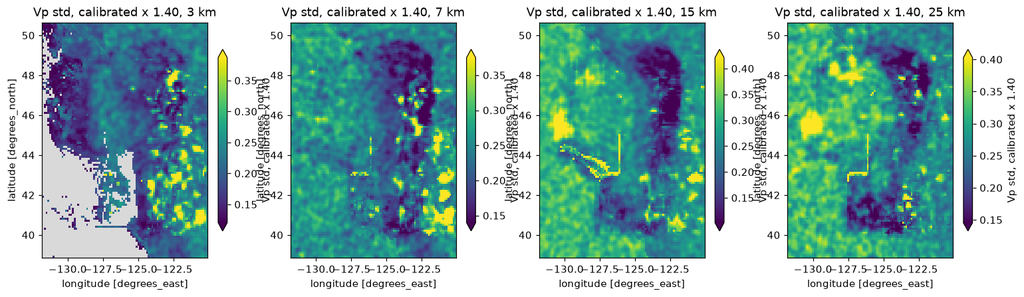

### Vs: ensemble standard deviation at depth (D-B094 calibrated: raw member std x 1.35) (grey: water, air or no value)

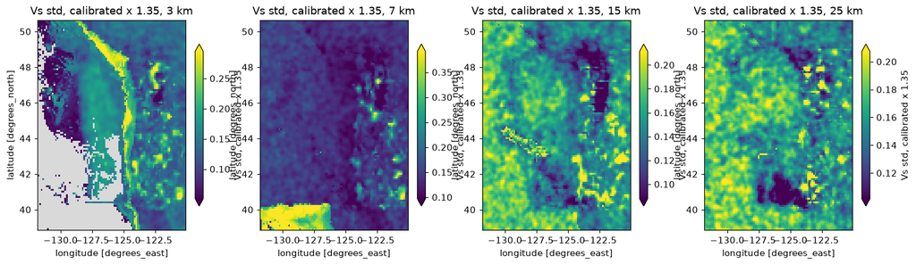

### VpVs: ensemble standard deviation at depth (not inflated) (grey: water, air or no value)

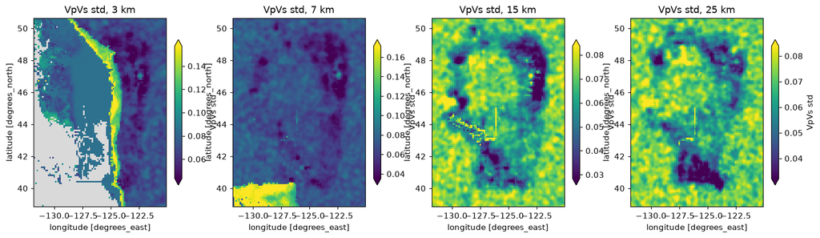

### Sections of the standard deviation, E-W at 44.5 N (calibrated, D-B094)

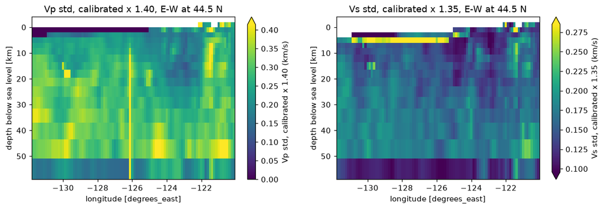

### Sections of the standard deviation, E-W at 47.5 N (calibrated, D-B094)

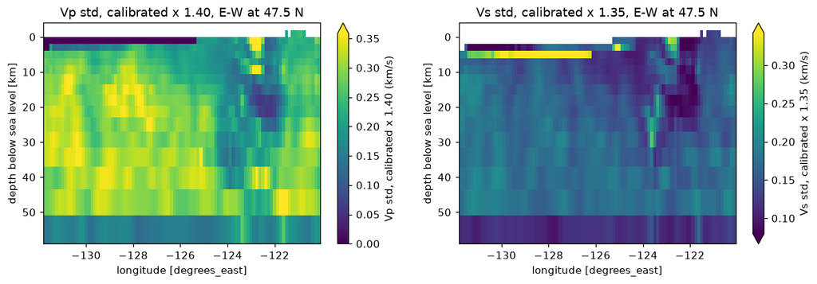

### Sections of the standard deviation, N-S at 125.0 W (calibrated, D-B094)

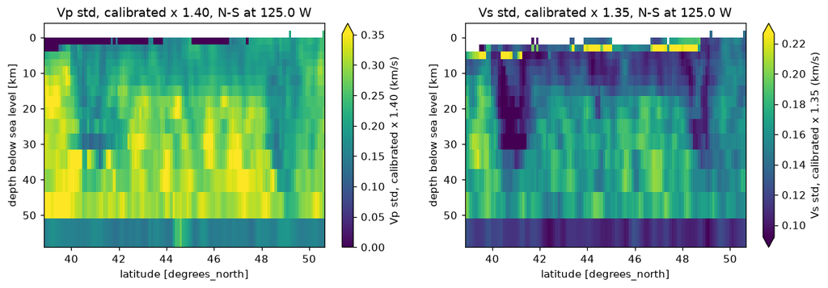